# WG_Homework

Ryan Langendorf, Courtney Collins, Nathalie Chardon, and Sam Straus

28/03/2023

### Aims:

1. Visualize BioTIME data in space and complete the following tasks sprinkled throughout code below
2. TASK 1: Calculate correlations and visualize time series of species pairs
3. TASK 2: Identify study pairs that have no data in their overlapping time series
4. TASK 3: Explore the effect of treatments on time series data
5. Ensure that R and GitHub are running smoothly through these exercises

Before getting into it, first we would like you to make sure that you have the most recent version of R installed.

### Update R and Rstudio

#### Updating R

To check your R version, run `R.version` in your R console. Please make sure you have R version 4.2.3 installed. To update your R version, visit https://cran.rstudio.com.

Note that for macOS, the newest version can either be loaded for silicon (M1 or newer) or Intel chips. Check what kind you have: Apple symbol in menu bar –> About this Mac –> look at “Processor” info

#### Updating Rstudio

Please make sure you have RStudio version 1.4.1106 installed. To check your version: RStudio in menu bar –> About RStudio –> look at Version info (2023.03.0+386 will show on Mac). Follow [this link](https://support--rstudio-com.netlify.app/products/rstudio/download/) to update your Rstudio. [This blog post](https://www.r-bloggers.com/2022/01/how-to-install-and-update-r-and-rstudio/) has useful information about installing if you have questions.

### Load libraries and input files

```r
# # LIBRARIES # #
library(tidyverse) # a suite of tidy packages useful for data manipulation
library("dplyr") # data manipulation
library("tibble") # help to create simple dataframes
library("readr") # flexible package for reading in data files
library("ggplot2") # data visualization
library("magrittr") # aids in syntax and piping

rm(list=ls())


# # INPUT FILES # #
load("../../data/tidy/collated_pairs.RData") #collated pairs of overlapping studies
load('../../data/prep_biotime/bio_pairs_10km.RData') #metadata of overlapping studies
```

### Visualize data

First, let’s look at the data to get a sense of their structure

```r
head(bio.pairs)
```

```
##        dist ID.1 ID.2     long.1     long.2     lat.1     lat.2       habitat.1
## 1 0.0000000  120  122 -169.45400 -169.45400  10.77800  10.77800  oceanic waters
## 2 0.0000000  408  409  -71.55892  -71.55892 -31.41595 -31.41595     Tidal flats
## 3 0.9659378  458  459   13.31245   13.32112  49.07963  49.07306 European forest
## 4 0.9454109  459  460   13.32112   13.31226  49.07306  49.07927 European forest
## 5 0.8961602  459  461   13.32112   13.31312  49.07306  49.07918 European forest
## 6 0.6850778  459  462   13.32112   13.31383  49.07306  49.07695 European forest
##         habitat.2                    taxa.1               taxa.2    organisms.1
## 1  pacific corals             Marine plants Marine invertebrates tropical algae
## 2     Tidal flats      Marine invertebrates                 Fish     turf algae
## 3 European forest Terrestrial invertebrates                Birds        beetles
## 4 European forest                     Birds                Fungi          Birds
## 5 European forest                     Birds                Fungi          Birds
## 6 European forest                     Birds                Fungi          Birds
##   organisms.2 no_species.1 no_species.2 start_year.1 start_year.2 end_year.1
## 1      corals          260          209         2002         2007       2008
## 2        fish           18           20         2012         2012       2013
## 3       Birds          150           44         2008         2010       2011
## 4       fungi           44           85         2010         2007       2014
## 5     lichens           44           20         2010         2007       2014
## 6     lichens           44            4         2010         2007       2014
##   end_year.2 overlap.years                         taxa.pairs
## 1       2010             1 Marine plants-Marine invertebrates
## 2       2013             1          Marine invertebrates-Fish
## 3       2014             1    Terrestrial invertebrates-Birds
## 4       2011             1                        Birds-Fungi
## 5       2011             1                        Birds-Fungi
## 6       2011             1                        Birds-Fungi
```

Each row reflects a pair of 2 time series that overlap (1D.1 and 1D.2). Each time series in a pair is defined by a unique taxon in a unique location. For example, the first pair is of Marine plants & Marine invertebrates (ID 120 & 122). Each taxon can have multiple species in it, e.g. there are 260 species of marine plants in the timeseries 1D=120. If we look closer at the organisms.1 columns we see these are all tropical algae. You will also notice that some IDs are in more than one pair, e.g. ID 459 (Birds) is in 4 of the 6 pairs shown here. Next, let’s look at how these studies are distributed across the globe. First we’ll draw a basic world map, add “y” or “n” for display of tropics and polar latitudes.

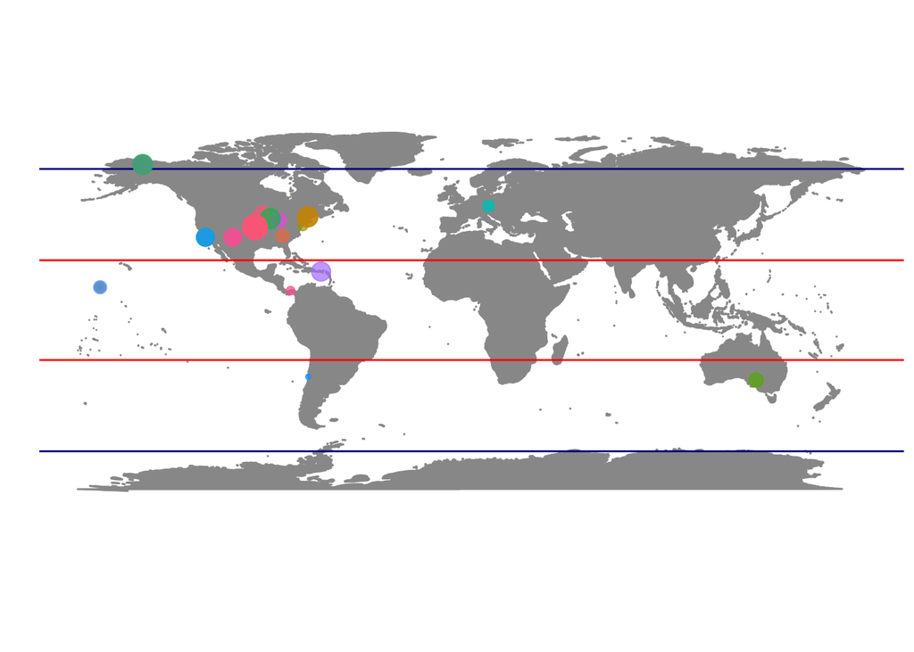

```r
## create function to draw world map
drawWorld<-function(lats) {
  world_map<-map_data("world")

  g1<-ggplot()+coord_fixed()+xlab("")+ylab("")
  g1<-g1+geom_polygon(data=world_map, aes(x=long, y=lat, group=group), colour="gray60", fill="gray60")
  g1<-g1+theme(panel.grid.major=element_blank(), panel.grid.minor=element_blank(),
               panel.background=element_rect(fill="white", colour="white"), axis.line=element_line(colour="white"),
               legend.position="none",axis.ticks=element_blank(), axis.text.x=element_blank(), axis.text.y=element_blank())

  if(lats=="y") {
    g1<-g1+geom_hline(yintercept=23.5, colour="red")+geom_hline(yintercept =-23.5, colour="red")
    g1<-g1+geom_hline(yintercept=66.5, colour="darkblue")+geom_hline(yintercept =-66.5, colour="darkblue")
  }
  else { return(g1) }
  return(g1)
}

# colors per taxa
taxaCol<-c('#ffffff','#ffffbf','#5e4fa2','#f46d43','#3288bd','#abdda4','#a8c614','#d53e4f','#66c2a5','#e6f598','#fee08b','#9e0142','#fdae61', '#fdae62')

# Now let's use the above function to plot these studies across the globe
(gplot <- drawWorld("y") +
  geom_point(data=bio.pairs, aes(x=long.1, y=lat.1, colour = taxa.pairs, size = overlap.years),
             alpha=I(0.7)))
```

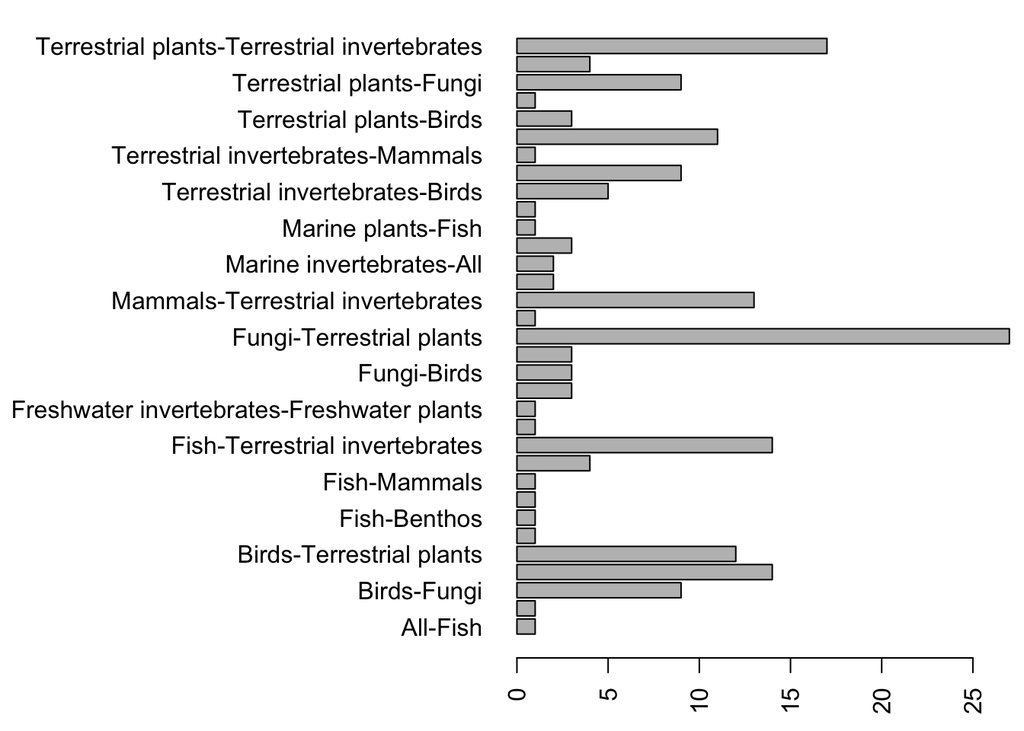

```r
# Let's also look at the distribution of taxa pairs in these data
par(mai = c(.5,3.5,.1,.1)) #create space under x-axis
barplot(table(bio.pairs$taxa.pairs), las = 2, horiz = T)
```

### Task 1: Species pairs

For this task, we will calculate correlations and visualize time series of species pairs. First, we will select a pair of time series, then we will extract the list of species in the two time series.

```r
## So let's explore a particular pair of time series with lots of overlapping data
pair=164

pair_1_ID <- bio.pairs$ID.1[pair]
pair_2_ID <- bio.pairs$ID.2[pair]

timeseries_1 <- collated.pairs %>% dplyr::filter(ID == pair_1_ID)
timeseries_2 <- collated.pairs %>% dplyr::filter(ID == pair_2_ID)


years_overlap <- unique(timeseries_1$YEAR)[unique(timeseries_1$YEAR) %in% unique(timeseries_2$YEAR)] %>% sort()

years_overlap # these timeseries have overlapping data for 30 years!
```

```
##  [1] 1983 1984 1985 1986 1987 1988 1989 1990 1991 1992 1993 1994 1995 1996 1997
## [16] 1998 1999 2000 2001 2002 2003 2004 2005 2006 2007 2008 2009 2010 2011 2012
## [31] 2013
```

```r
## Let's make a list of the species in these two timeseries
timeseries_1_species <- timeseries_1$SPECIES %>% unique()
timeseries_1_species = timeseries_1_species[!is.na(timeseries_1_species)]
timeseries_1_species_length <- sapply(timeseries_1_species, function(x){
  timeseries_1 %>%
    dplyr::filter(SPECIES == x) %>%
    dplyr::select(YEAR) %>%
    unique() %>%
    unlist() %>%
    length()
})

timeseries_2_species <- timeseries_2$SPECIES %>% unique()
timeseries_2_species = timeseries_2_species[!is.na(timeseries_2_species)]
timeseries_2_species_length <- sapply(timeseries_2_species, function(x){
  timeseries_2 %>%
    dplyr::filter(SPECIES == x) %>%
    dplyr::select(YEAR) %>%
    unique() %>%
    unlist() %>%
    length()
})
```

Next, we will randomly select a species from each timeseries, with at least 10 observations to explore.

```r
sp1 = timeseries_1_species[sample(x = which(timeseries_1_species_length > 10), size = 1)]
sp2 = timeseries_2_species[sample(x = which(timeseries_2_species_length > 10), size = 1)]


#let's look at the data for one of the species
sp1_data <- timeseries_1 %>%
  dplyr::filter(
    SPECIES == sp1,
    YEAR %in% years_overlap
  )
head(sp1_data)
```

```
##         X  ID DAY MONTH YEAR    SAMPLE_DESC PLOT ID_SPECIES LATITUDE LONGITUDE
## 1 6442684 311  NA    NA 1986 1986_AU_N04D-W NULL      43025 39.08333 -96.58333
## 2 6442878 311  NA    NA 1983 1983_SP_001D-E NULL      43025 39.08333 -96.58333
## 3 6442884 311  NA    NA 1983 1983_SP_020B-E NULL      43025 39.08333 -96.58333
## 4 6442890 311  NA    NA 1983 1983_SP_N20B-S NULL      43025 39.08333 -96.58333
## 5 6442941 311  NA    NA 1984 1984_SP_N01B-W NULL      43025 39.08333 -96.58333
## 6 6442952 311  NA    NA 1985 1985_AU_001D-W NULL      43025 39.08333 -96.58333
##   sum.allrawdata.ABUNDANCE sum.allrawdata.BIOMASS      GENUS SPECIES
## 1                        1                     NA Synaptomys cooperi
## 2                        1                     NA Synaptomys cooperi
## 3                        2                     NA Synaptomys cooperi
## 4                        1                     NA Synaptomys cooperi
## 5                        1                     NA Synaptomys cooperi
## 6                        1                     NA Synaptomys cooperi
##        GENUS_SPECIES ABUNDANCE_TYPE BIOMASS_TYPE
## 1 Synaptomys cooperi          Count         <NA>
## 2 Synaptomys cooperi          Count         <NA>
## 3 Synaptomys cooperi          Count         <NA>
## 4 Synaptomys cooperi          Count         <NA>
## 5 Synaptomys cooperi          Count         <NA>
## 6 Synaptomys cooperi          Count         <NA>
```

Notice that there are multiple observations of this species within the same year with different abundance values. These are due to sampling occurring at different spatial locations within the study area (for example plots). Because we want to look at how the abundances of species pairs co-vary over time, for now, let’s take the average of all spatial replicates within each year for each species.

TASK 1: There are many reasons why this might not be the most accurate approach, try to think of some different ideas for how we can best approach this issue and bring them to the working group?

```r
sp1_data <- timeseries_1 %>%
  dplyr::filter(
    SPECIES == sp1,
    YEAR %in% years_overlap
  ) %>%
  dplyr::group_by(YEAR) %>%
  dplyr::summarise(
    Abundance = sum( ## This assumes there will only ever be either abundance or biomass data
      mean(sum.allrawdata.ABUNDANCE, na.rm = TRUE),
      mean(sum.allrawdata.BIOMASS, na.rm = TRUE),
      na.rm = TRUE
    )
  ) %>%
  dplyr::ungroup() %>%
  dplyr::arrange(YEAR)%>%
  distinct(.)

sp2_data <- timeseries_2 %>%
  dplyr::filter(
    SPECIES == sp2,
    YEAR %in% years_overlap
  ) %>%
  dplyr::group_by(YEAR) %>%
  dplyr::summarize(
    Abundance = sum( ## This assumes there will only ever be either abundance or biomass data
      mean(sum.allrawdata.ABUNDANCE, na.rm = TRUE),
      mean(sum.allrawdata.BIOMASS, na.rm = TRUE),
      na.rm = TRUE
    )
  ) %>%
  dplyr::ungroup() %>%
  dplyr::arrange(YEAR)
```

You will remember that the overlap we calculated above is at the taxon level, so for all species in the timeseries. But each pair of species may not overlap across all the years. We need to filter the data by only the years that these species overlap in sampling. This next code chunk will filter by overlapping years and calculate the correlation between species.

```r
## filter the data by only the years that these species overlap in sampling
sp1_data %<>% dplyr::filter(YEAR %in% sp2_data$YEAR)
sp2_data %<>% dplyr::filter(YEAR %in% sp1_data$YEAR)

## Calculate correlation between two species
cor_pair <- cor(sp1_data$Abundance, sp2_data$Abundance)
```

Finally, we can plot our time series and correlations between species over time.

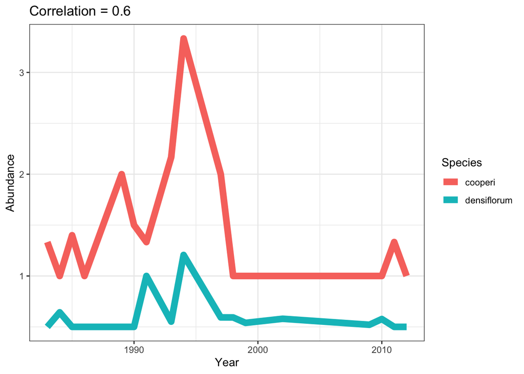

```r
## Plot our timeseries
fig_data <- dplyr::bind_rows(
  sp1_data %>% dplyr::mutate(Species = sp1),
  sp2_data %>% dplyr::mutate(Species = sp2)
)

## Plot correlation over time
fig_data %>%
  ggplot() +
  theme_bw() +
  geom_line(
    aes(
      x = YEAR,
      y = Abundance,
      color = Species
    ),
    linewidth = 3
  ) +
  labs(
    title = paste0("Correlation = ", round(cor_pair, 2))
  ) + xlab("Year")
```

How does it look? Are your species highly correlated over time? Positively or negatively? Let’s look back at the metadata and see what kind of organisms we are looking at.

```r
bio.pairs%>%subset(ID.1==pair_1_ID&ID.2==pair_2_ID)
```

```
##             dist ID.1 ID.2    long.1    long.2    lat.1    lat.2
## 164 0.0002590115  311  355 -96.58333 -96.58333 39.08333 39.08333
##             habitat.1 habitat.2  taxa.1             taxa.2   organisms.1
## 164 Tallgrass prairie   Prairie Mammals Terrestrial plants Small mammals
##     organisms.2 no_species.1 no_species.2 start_year.1 start_year.2 end_year.1
## 164      plants           15          324         1981         1983       2013
##     end_year.2 overlap.years                 taxa.pairs
## 164       2015            30 Mammals-Terrestrial plants
```

So you can see we are looking at small mammals and plants in tallgrass prairie. It seems like, biologically, we might expect these groups to co-vary. Does your species pair reflect this? If you want to dig deeper, let’s look at the full species names.

```r
timeseries_1%>%filter(grepl(sp1, SPECIES))%>%select(GENUS_SPECIES)%>%distinct(.)
```

```
##        GENUS_SPECIES
## 1 Synaptomys cooperi
```

```r
timeseries_2%>%filter(grepl(sp2, SPECIES))%>%select(GENUS_SPECIES)%>%distinct(.)
```

```
##          GENUS_SPECIES
## 1 Lepidium densiflorum
```

Feel free to research more about these individual species to inform why they may or may not correlate over time.

### Task 2: Check for zeroes in data for taxa pairs in overlapping years

Next, let’s make the same graph as above, but at the taxa level (rather than species level). Using the same pair that we identified at the start of Task 1, we will extract abundance, calculate the correlations, and plot the time series and correlations at the taxon level.

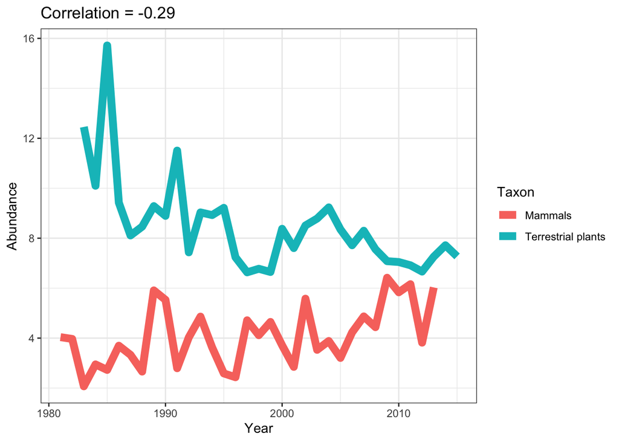

```r
# Abundance data for taxa 1 from the pair identified at the start of the last section
taxon1_data <- timeseries_1 %>%
  dplyr::group_by(YEAR) %>%
  dplyr::summarise(
    Abundance = sum( ## This assumes there will only ever be either abundance or biomass data
      mean(sum.allrawdata.ABUNDANCE, na.rm = TRUE),
      mean(sum.allrawdata.BIOMASS, na.rm = TRUE),
      na.rm = TRUE
    )
  ) %>%
  dplyr::ungroup() %>%
  dplyr::arrange(YEAR)%>%
  distinct(.)

# Abundance data for taxa 2 from the pair identified at the start of the last section
taxon2_data <- timeseries_2 %>%
  dplyr::group_by(YEAR) %>%
  dplyr::summarise(
    Abundance = sum( ## This assumes there will only ever be either abundance or biomass data
      mean(sum.allrawdata.ABUNDANCE, na.rm = TRUE),
      mean(sum.allrawdata.BIOMASS, na.rm = TRUE),
      na.rm = TRUE
    )
  ) %>%
  dplyr::ungroup() %>%
  dplyr::arrange(YEAR)%>%
  distinct(.)

# Calculate correlation between two taxa
cor_pair <- cor(taxon1_data$Abundance, taxon2_data$Abundance)

# Plot our timeseries
fig_data <- dplyr::bind_rows(
  taxon1_data %>% dplyr::mutate(Taxon = bio.pairs$taxa.1[pair]),
  taxon2_data %>% dplyr::mutate(Taxon = bio.pairs$taxa.2[pair])
)

# Plot correlation over time
fig_data %>%
  ggplot() +
  theme_bw() +
  geom_line(
    aes(
      x = YEAR,
      y = Abundance,
      color = Taxon
    ),
    linewidth = 3
  ) +
  labs(
    title = paste0("Correlation = ", round(cor_pair, 2))
  ) + xlab("Year")
```

How does this graph compare to the species-level graph you made? Is the correlation higher or lower?

This example had abundance data for both taxa groups in all years. What about taxa pairs that have many 0s in their overlapping years? Let’s look for an example of such a pair. We’ll do this using a for-loop.

```r
zeros <- data.frame(study_id = NA, years = NA) #initialize empty dataframe

for (i in 1:nrow(bio.pairs)) {

  # create dataframe for each timeseries in a pair
  timeseries_1 <- collated.pairs %>% dplyr::filter(ID == bio.pairs$ID.1[i])
  timeseries_2 <- collated.pairs %>% dplyr::filter(ID == bio.pairs$ID.2[i])

  # summarize mean abundance per year for taxon 1
  taxon1_data <- timeseries_1 %>%
    dplyr::group_by(YEAR) %>%
    dplyr::summarise(
      Abundance1 = sum( ## This assumes there will only ever be either abundance or biomass data
        mean(sum.allrawdata.ABUNDANCE, na.rm = TRUE),
        mean(sum.allrawdata.BIOMASS, na.rm = TRUE),
        na.rm = TRUE
      )
    )

  # summarize mean abundance per year for taxon 2
  taxon2_data <- timeseries_2 %>%
    dplyr::group_by(YEAR) %>%
    dplyr::summarise(
      Abundance2 = sum( ## This assumes there will only ever be either abundance or biomass data
        mean(sum.allrawdata.ABUNDANCE, na.rm = TRUE),
        mean(sum.allrawdata.BIOMASS, na.rm = TRUE),
        na.rm = TRUE
      )
    )

  # keep only overlapping years
  tax12_data <- inner_join(taxon1_data, taxon2_data, by = 'YEAR')

  # identify and record any years of study ID that have 0s in abundance or biomass
  if (0 %in% tax12_data$Abundance1) {

    zeros <- rbind(zeros,
                   c(bio.pairs$ID.1[i], paste(min(tax12_data$YEAR), max(tax12_data$YEAR), sep = '_')))
  }
}

# Look at zeros
zeros
```

```
##   study_id years
## 1       NA    NA
```

It turns out there are no overlapping years with zeros in abundance or biomass! That’s great news, and it will make our analyses easier.

TASK 2: Think about some reasons why having 0s in taxa 1 and taxa 2 of overlapping pairs of years could present some difficulties in our analyses of asking whether changes in abundance in taxa in one year can predict changes in abundance of another taxa.

### Task 3: Treatments

Now let’s consider the broader stud(ies) and experiments in which these data were collected. We can read in a dataframe with additional metadata for each study from BioTime.

```r
load('../../data/prep_biotime/meta_pairs_10km.RData') #biotime metadata for 10 km pairs to use
```

First, we will filter by unique IDs, and then explore the methods of the studies.

```r
#filter for our unique IDs
pair=164

pair_1_ID <- bio.pairs$ID.1[pair]
pair_2_ID <- bio.pairs$ID.2[pair]

meta.pairs<-filter(meta.pairs, STUDY_ID==pair_1_ID|STUDY_ID==pair_2_ID)

#let's look at the columns that describe the methods of these studies
head(meta.pairs$METHODS)
```

```
## [1] "Data set contains seasonal summaries (spring and autumn) of the number of individuals of each species of small mammal captured (relative abundance) on each grassland trapline. Each record contains year. season. trapline and number of individuals captured of each species. These live trap reco…
## [2] "The transects were permanently layed out in the current format of 4 transects (A-D) each with 5 plots for each watershed. Transect E only occurred on watershed N20B florence in 1986 and 1987. This transect is the same as the current transect D for this watershed and soil type. The old transe…
```

```r
head(meta.pairs$GENERAL_TREAT)
```

```
## [1] "14 permanent traplines established on seven fire-grazing treatments (two traplines per treatment)"
## [2] NA
```

We can see for ID 311 that there were seven fire and grazing treatments with 2 trap-lines per treatment. However, we have not accounted for these different treatments in any way when plotting the species correlations above. This could potentially cause issues in our interpretations of the different time series.

TASK 3: Try to think of some different ideas for how we might account for this and bring them to the working group.

Next, let’s see where these studies were located.

```r
head(meta.pairs$CENT_LAT)
```

```
## [1] 39.08333 39.08333
```

```r
head(meta.pairs$CENT_LONG)
```

```
## [1] -96.58333 -96.58333
```

So it appears these studies were in the exact same location. Let’s dig a bit deeper.

```r
head(meta.pairs$DATA_SOURCE)
```

```
## [1] "Konza Prairie Long-Term Ecological Research"
## [2] "Konza LTER"
```

Upon further investigation, we see that they are both from the Konza Prairie LTER, but they don’t both report the same treatments. We might need to do some more digging to sort out these inconsistencies…

See if you can find any other inconsistencies in the meta-data for these 2 studies, or look through the entire meta.pairs dataframe to see if anything else looks concerning!